# IPV4

Hoguin

12/01/2021

## Adresses de classe A

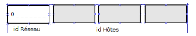

- Le masque de sous-réseau associée à une adresse de classe A est : **255.0.0.0**
- Dans un réseau de classe A l’identifiant réseau $x$ est compris dans l’intervalle entier $[1;127]$
- Dans un réseau de classe A on peut donc identifier $2^{24}-2$ machines soit $16\,777\,214$ de machines,

### Exemples d’adresses de classe A

1. **20.10.10.10** :
- identifiant réseau : **20.0.0.0**
- identifiant machine : **0.10.10.10**
- masque de sous-réseau : **255.0.0.0**
2. **100.0.255.1** :
- identifiant réseau : **100.0.0.0**
- identifiant machine : **0.0.255.1**
- masque de sous-réseau : **255.0.0.0**

## Adresses de classe B

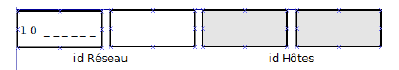

- Le masque de sous-réseau associée à une adresse de classe B est : **255.255.0.0**
- Dans un réseau de classe B l’identifiant réseau $x$ est compris dans l’intervalle entier $[128;191].[0;255]$
- Dans un réseau de classe B on peut donc identifier $2^{16}-2$ machines soit $65\,534$ de machines

### Exemples d’adresses de classe B

1. **128.2.34.56**
- identifiant réseau : **128.2.0.0**
- identifiant machine : **0.0.34.56**
- masque de sous-réseau : **255.255.0.0**
2. **172.16.6.0**
- identifiant réseau : **172.16.0.0**
- identifiant machine : **0.0.6.0**
- masque de sous-réseau : **255.255.0.0**

## Adresses de classe C

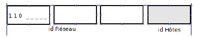

- Le masque de sous-réseau associée à une adresse de classe C est : **255.255.255.0**
- Dans un réseau de classe C l’identifiant réseau $x$ est compris dans l’intervalle entier $[192;223].[0;255].[0;255]$
- Dans un réseau de classe C on peut donc identifier $2^{8}-2$ machines soit $254$ machines

### Exemples d’adresses de classe C

1. **192.168.1.15**
- identifiant réseau : **192.168.1.0**
- identifiant machine : **0.0.0.15**
- masque de sous-réseau : **255.255.255.0**
2. **193.51.29.1**
- identifiant réseau : **193.51.29.0**
- identifiant machine : **0.0.0.1**
- masque de sous-réseau : **255.255.255.0**

## Utilisation du masque

Le masque de sous-réseau est utilisé pour déterminer l’identifiant de réseau. On procède ainsi :

| Adresse | décimal | binaire |
| --- | --- | --- |
| Adresse IP | 190.30.24.120 | 10111110.00011110.00011000.01111000 |
| mask | 255.255.240.0 | 11111111.11111111.11110000.00000000 |
| Opération Logique ET | ??? | 10111110.00011110.00010000.00000 |

rappels :

- a ET 0 = 0 (quelque soit la valeur de a)
- a ET 1 = a

L’identifiant réseau est donc **190.30.16.0**

## La notation CIDR

### Définition :

CIDR est l’acronyme de **Classless Inter Domain Routing**

### Objectifs

Le premier objectif de la notation CIDR est d’indiquer la longueur du masque (en nombre de bits) du sous réseau associé. On procède ainsi **10.23.12.34/8** le **/8** indique que le masque est codé sur **8** bits. Le masque est donc égal à **255.0.0.0**

### Un exemple

- l’adresse IP suivante **10.23.12.34** est en principe une adresse de classe A
- Avec la notation CIDR, on peut désormais la faire appartenir à une autre classe :
  - **10.23.12.34/16**, le masque devient 255.255.0.0. et l’identifiant réseau est **10.23.0.0**

### Deuxième objectif

Le deuxième objectif est de permettre de faire de l’adressage en sous-réseau logique

Exemple :

- l’adresse IP suivante : **192.168.1.0/24** est une adresse de classe C.
- Si l’administrateur décide de construire **3** sous réseaux logiques, il va prendre **2** bits au dela du masque pour faire l’adressage de sous réseau logique.

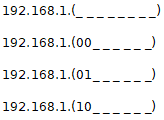

#### Résultat

| Sous réseau | @Sous-Réseau | masque CIDR | nbre de machine |
| --- | --- | --- | --- |
| SR num 1 | 192.168.1.0 | /26 | 62 |
| SR num 2 | 192.168.1.64 | /26 | 62 |
| SR num 3 | 192.168.1.128 | /26 | 62 |

### Adresse IP de broadcast

Il est possible d’adresser un message IP en **broadcast**. L’adresse IP de broadcast est obtenue en remplaçant dans la partie **host** d’une adresse IP tous les bits à **1**

Exemples :

1. 192.168.1.0/24 a pour broadcast : 192.168.1.255
2. 193.23.34.45/16 a pour broadcast : 193.23.255.255
3. 100.20.20.10/12 a pour broadcast : 100.31.255.255

### Explication pour le dernier exemple

- 100.20.20.10/12 a pour masque 255.240.0.0 et donc l’identifiant réseau est : 100.16.0.0 (faire un ET logique bit à bit entre l’adresse IP et le masque)
- Ce qui correspond en binaire à :

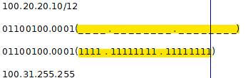